# 📊 Customer Behavior Analysis Project

# Customer Behavior Analysis

**Course**: IIMK's Professional Certificate in Data Science and Artificial Intelligence for Managers  
**Student Name**: Lalit Nayyar  
**Email ID**: lalitnayyar@gmail.com  
**Assignment Name**: Week 4: Required Assignment 4.1

## Introduction

This notebook analyzes customer behavior data from an online retail platform to derive meaningful insights for business decision-making. We'll focus on understanding purchasing patterns, customer segmentation, and transaction trends.

## Data Description and Preparation

```python
# Import required libraries
import pandas as pd
import numpy as np
import matplotlib.pyplot as plt
import seaborn as sns

# Set display options
pd.set_option('display.max_columns', None)
pd.set_option('display.float_format', lambda x: '%.3f' % x)
```

```python
# Load and examine the data
try:
    # Load data
    print("Loading data...")
    df = pd.read_excel('Online Retail.xlsx')

    # Display basic information
    print("Dataset Info:")
    print(f"Number of records: {len(df):,}")
    print(f"Number of columns: {len(df.columns)}")
    print("Columns:", df.columns.tolist())

    # Display sample
    print("Sample of the data:")
    display(df.head())

    # Basic statistics
    print("Basic statistics:")
    display(df.describe())

except Exception as e:
    print(f"Error loading data: {e}")
    df = None
```

```
Loading data...
Dataset Info:
Number of records: 541,909
Number of columns: 8
Columns: ['InvoiceNo', 'StockCode', 'Description', 'Quantity', 'InvoiceDate', 'UnitPrice', 'CustomerID', 'Country']
Sample of the data:
```

|  | InvoiceNo | StockCode | Description | Quantity | InvoiceDate | UnitPrice | CustomerID | Country |
| --- | --- | --- | --- | --- | --- | --- | --- | --- |
| 0 | 536365 | 85123A | WHITE HANGING HEART T-LIGHT HOLDER | 6 | 2010-12-01 08:26:00 | 2.550 | 17850.000 | United Kingdom |
| 1 | 536365 | 71053 | WHITE METAL LANTERN | 6 | 2010-12-01 08:26:00 | 3.390 | 17850.000 | United Kingdom |
| 2 | 536365 | 84406B | CREAM CUPID HEARTS COAT HANGER | 8 | 2010-12-01 08:26:00 | 2.750 | 17850.000 | United Kingdom |
| 3 | 536365 | 84029G | KNITTED UNION FLAG HOT WATER BOTTLE | 6 | 2010-12-01 08:26:00 | 3.390 | 17850.000 | United Kingdom |
| 4 | 536365 | 84029E | RED WOOLLY HOTTIE WHITE HEART. | 6 | 2010-12-01 08:26:00 | 3.390 | 17850.000 | United Kingdom |

```
Basic statistics:
```

|  | Quantity | InvoiceDate | UnitPrice | CustomerID |
| --- | --- | --- | --- | --- |
| count | 541909.000 | 541909 | 541909.000 | 406829.000 |
| mean | 9.552 | 2011-07-04 13:34:57.156386048 | 4.611 | 15287.691 |
| min | -80995.000 | 2010-12-01 08:26:00 | -11062.060 | 12346.000 |
| 25% | 1.000 | 2011-03-28 11:34:00 | 1.250 | 13953.000 |
| 50% | 3.000 | 2011-07-19 17:17:00 | 2.080 | 15152.000 |
| 75% | 10.000 | 2011-10-19 11:27:00 | 4.130 | 16791.000 |
| max | 80995.000 | 2011-12-09 12:50:00 | 38970.000 | 18287.000 |
| std | 218.081 | NaN | 96.760 | 1713.600 |

### Data Structure Analysis

The Online Retail dataset is a **structured dataset** with the following characteristics:

- Each row represents a transaction
- Contains numerical and categorical variables
- Has a clear schema with defined columns

```python
# Check for missing values
print("Missing values in each column:")
print("-" * 50)
print(df.isnull().sum())

# Check for duplicates
print("\nNumber of duplicate rows:")
print("-" * 50)
print(df.duplicated().sum())
```

```
Missing values in each column:
--------------------------------------------------
InvoiceNo           0
StockCode           0
Description      1454
Quantity            0
InvoiceDate         0
UnitPrice           0
CustomerID     135080
Country             0
dtype: int64

Number of duplicate rows:
--------------------------------------------------
5268
```

```python
def clean_data(df):
    # Create a copy of the dataframe
    df_clean = df.copy()

    # Remove rows with missing values
    df_clean = df_clean.dropna()

    # Remove duplicates
    df_clean = df_clean.drop_duplicates()

    # Filter out rows with quantity <= 0 or unit price <= 0
    df_clean = df_clean[(df_clean['Quantity'] > 0) & (df_clean['UnitPrice'] > 0)]

    # Add a TotalAmount column
    df_clean['TotalAmount'] = df_clean['Quantity'] * df_clean['UnitPrice']

    return df_clean

# Clean the data
df_clean = clean_data(df)

# Display basic statistics of the cleaned dataset
print("Cleaned dataset statistics:")
print("-" * 50)
df_clean.describe()
```

```
Cleaned dataset statistics:
--------------------------------------------------
```

|  | Quantity | InvoiceDate | UnitPrice | CustomerID | TotalAmount |
| --- | --- | --- | --- | --- | --- |
| count | 392692.000 | 392692 | 392692.000 | 392692.000 | 392692.000 |
| mean | 13.120 | 2011-07-10 19:13:07.771892480 | 3.126 | 15287.844 | 22.631 |
| min | 1.000 | 2010-12-01 08:26:00 | 0.001 | 12346.000 | 0.001 |
| 25% | 2.000 | 2011-04-07 11:12:00 | 1.250 | 13955.000 | 4.950 |
| 50% | 6.000 | 2011-07-31 12:02:00 | 1.950 | 15150.000 | 12.450 |
| 75% | 12.000 | 2011-10-20 12:53:00 | 3.750 | 16791.000 | 19.800 |
| max | 80995.000 | 2011-12-09 12:50:00 | 8142.750 | 18287.000 | 168469.600 |
| std | 180.493 | NaN | 22.242 | 1713.540 | 311.099 |

### Data Preprocessing Summary

The following preprocessing steps were performed:

1. Removed missing values
2. Removed duplicate transactions
3. Filtered out invalid transactions (negative or zero quantity/price)
4. Added TotalAmount column for transaction value analysis

The cleaned dataset is now ready for further analysis of customer behavior patterns.

## 📊 Descriptive Analysis

# Customer Behavior Descriptive Analysis

**Course**: IIMK's Professional Certificate in Data Science and Artificial Intelligence for Managers  
**Student Name**: Lalit Nayyar  
**Email ID**: lalitnayyar@gmail.com  
**Assignment Name**: Week 4: Required Assignment 4.1

## Descriptive Analytics Section

In this section, we'll perform detailed descriptive analytics to understand customer behavior patterns and trends.

```python
# Import required libraries
import pandas as pd
import numpy as np
import matplotlib.pyplot as plt
import seaborn as sns
from datetime import datetime

# Set visualization style

plt.style.use('seaborn-v0_8')
plt.rcParams['figure.figsize'] = [14, 7]
plt.rcParams['axes.grid'] = True
plt.rcParams['grid.alpha'] = 0.3
plt.rcParams['axes.labelsize'] = 12
plt.rcParams['axes.titlesize'] = 14
plt.rcParams['xtick.labelsize'] = 11
plt.rcParams['ytick.labelsize'] = 11
plt.rcParams['lines.linewidth'] = 2.0
plt.rcParams['font.size'] = 11
plt.rcParams['axes.prop_cycle'] = plt.cycler(color=[
    '#1A237E',  # Dark blue
    '#BF360C',  # Dark orange
    '#1B5E20',  # Dark green
    '#4A148C',  # Dark purple
    '#212121',  # Near black
    '#01579B'   # Navy blue
])
plt.rcParams['axes.edgecolor'] = '#212121'
plt.rcParams['axes.labelcolor'] = '#212121'
plt.rcParams['xtick.color'] = '#212121'
plt.rcParams['ytick.color'] = '#212121'
  # Use default matplotlib style
sns.set_theme(style="whitegrid")  # Set seaborn style
sns.set_palette('husl')  # Set color palette

# Increase font size for better readability
plt.rcParams['font.size'] = 12
plt.rcParams['axes.labelsize'] = 12
plt.rcParams['axes.titlesize'] = 14
plt.rcParams['xtick.labelsize'] = 10
plt.rcParams['ytick.labelsize'] = 10

# Display settings for pandas
pd.set_option('display.max_columns', None)
pd.set_option('display.float_format', lambda x: '%.3f' % x)
```

```python
def clean_data(df):
    """
    Clean the retail dataset by:
    1. Removing missing values
    2. Removing cancelled orders (those with 'C' in InvoiceNo)
    3. Ensuring positive quantities and prices
    4. Converting InvoiceDate to datetime
    """
    if df is None:
        return None

    # Create a copy of the dataframe
    df_clean = df.copy()

    # Remove rows with missing values
    df_clean = df_clean.dropna()

    # Remove cancelled orders (those with 'C' in InvoiceNo)
    df_clean = df_clean[~df_clean['InvoiceNo'].astype(str).str.contains('C')]

    # Ensure positive quantities and prices
    df_clean = df_clean[(df_clean['Quantity'] > 0) & (df_clean['UnitPrice'] > 0)]

    # Convert InvoiceDate to datetime if it's not already
    if not pd.api.types.is_datetime64_any_dtype(df_clean['InvoiceDate']):
        df_clean['InvoiceDate'] = pd.to_datetime(df_clean['InvoiceDate'])

    # Reset index
    df_clean = df_clean.reset_index(drop=True)

    print("Data cleaning summary:")
    print(f"Original records: {len(df)}")
    print(f"Clean records: {len(df_clean)}")
    print(f"Removed records: {len(df) - len(df_clean)}")

    return df_clean
```

```python
# Load and prepare the data
df = pd.read_excel('Online Retail.xlsx')
print("Original data shape:", df.shape)

# Clean the data
df_clean = clean_data(df)
print("Cleaned data shape:", df_clean.shape)

# Calculate total amount for each transaction
df_clean['TotalAmount'] = df_clean['Quantity'] * df_clean['UnitPrice']
print("Sample of cleaned data with total amount:")
display(df_clean.head())

# Basic statistics of the cleaned dataset
print("Basic statistics of numerical columns:")
display(df_clean.describe())
```

```
Original data shape: (541909, 8)
Data cleaning summary:
Original records: 541909
Clean records: 397884
Removed records: 144025
Cleaned data shape: (397884, 8)
Sample of cleaned data with total amount:
```

|  | InvoiceNo | StockCode | Description | Quantity | InvoiceDate | UnitPrice | CustomerID | Country | TotalAmount |
| --- | --- | --- | --- | --- | --- | --- | --- | --- | --- |
| 0 | 536365 | 85123A | WHITE HANGING HEART T-LIGHT HOLDER | 6 | 2010-12-01 08:26:00 | 2.550 | 17850.000 | United Kingdom | 15.300 |
| 1 | 536365 | 71053 | WHITE METAL LANTERN | 6 | 2010-12-01 08:26:00 | 3.390 | 17850.000 | United Kingdom | 20.340 |
| 2 | 536365 | 84406B | CREAM CUPID HEARTS COAT HANGER | 8 | 2010-12-01 08:26:00 | 2.750 | 17850.000 | United Kingdom | 22.000 |
| 3 | 536365 | 84029G | KNITTED UNION FLAG HOT WATER BOTTLE | 6 | 2010-12-01 08:26:00 | 3.390 | 17850.000 | United Kingdom | 20.340 |
| 4 | 536365 | 84029E | RED WOOLLY HOTTIE WHITE HEART. | 6 | 2010-12-01 08:26:00 | 3.390 | 17850.000 | United Kingdom | 20.340 |

```
Basic statistics of numerical columns:
```

|  | Quantity | InvoiceDate | UnitPrice | CustomerID | TotalAmount |
| --- | --- | --- | --- | --- | --- |
| count | 397884.000 | 397884 | 397884.000 | 397884.000 | 397884.000 |
| mean | 12.988 | 2011-07-10 23:41:23.511023360 | 3.116 | 15294.423 | 22.397 |
| min | 1.000 | 2010-12-01 08:26:00 | 0.001 | 12346.000 | 0.001 |
| 25% | 2.000 | 2011-04-07 11:12:00 | 1.250 | 13969.000 | 4.680 |
| 50% | 6.000 | 2011-07-31 14:39:00 | 1.950 | 15159.000 | 11.800 |
| 75% | 12.000 | 2011-10-20 14:33:00 | 3.750 | 16795.000 | 19.800 |
| max | 80995.000 | 2011-12-09 12:50:00 | 8142.750 | 18287.000 | 168469.600 |
| std | 179.332 | NaN | 22.098 | 1713.142 | 309.071 |

### 2. Popular Products Analysis

```
Top 10 Products by Quantity Sold:
```

| Description | Quantity | TotalAmount | TransactionCount |
| --- | --- | --- | --- |
| PAPER CRAFT , LITTLE BIRDIE | 80995 | 168469.600 | 1 |
| MEDIUM CERAMIC TOP STORAGE JAR | 77916 | 81416.730 | 198 |
| WORLD WAR 2 GLIDERS ASSTD DESIGNS | 54415 | 13586.250 | 473 |
| JUMBO BAG RED RETROSPOT | 46181 | 85220.780 | 1618 |
| WHITE HANGING HEART T-LIGHT HOLDER | 36725 | 100448.150 | 2028 |
| ASSORTED COLOUR BIRD ORNAMENT | 35362 | 56580.340 | 1408 |
| PACK OF 72 RETROSPOT CAKE CASES | 33693 | 16394.530 | 1068 |
| POPCORN HOLDER | 30931 | 23427.710 | 657 |
| RABBIT NIGHT LIGHT | 27202 | 51346.200 | 842 |
| MINI PAINT SET VINTAGE | 26076 | 16039.240 | 325 |

```
Top 10 Products by Revenue:
```

| Description | Quantity | TotalAmount | TransactionCount |
| --- | --- | --- | --- |
| PAPER CRAFT , LITTLE BIRDIE | 80995 | 168469.600 | 1 |
| REGENCY CAKESTAND 3 TIER | 12402 | 142592.950 | 1723 |
| WHITE HANGING HEART T-LIGHT HOLDER | 36725 | 100448.150 | 2028 |
| JUMBO BAG RED RETROSPOT | 46181 | 85220.780 | 1618 |
| MEDIUM CERAMIC TOP STORAGE JAR | 77916 | 81416.730 | 198 |
| POSTAGE | 3120 | 77803.960 | 1099 |
| PARTY BUNTING | 15291 | 68844.330 | 1396 |
| ASSORTED COLOUR BIRD ORNAMENT | 35362 | 56580.340 | 1408 |
| Manual | 7173 | 53779.930 | 284 |
| RABBIT NIGHT LIGHT | 27202 | 51346.200 | 842 |

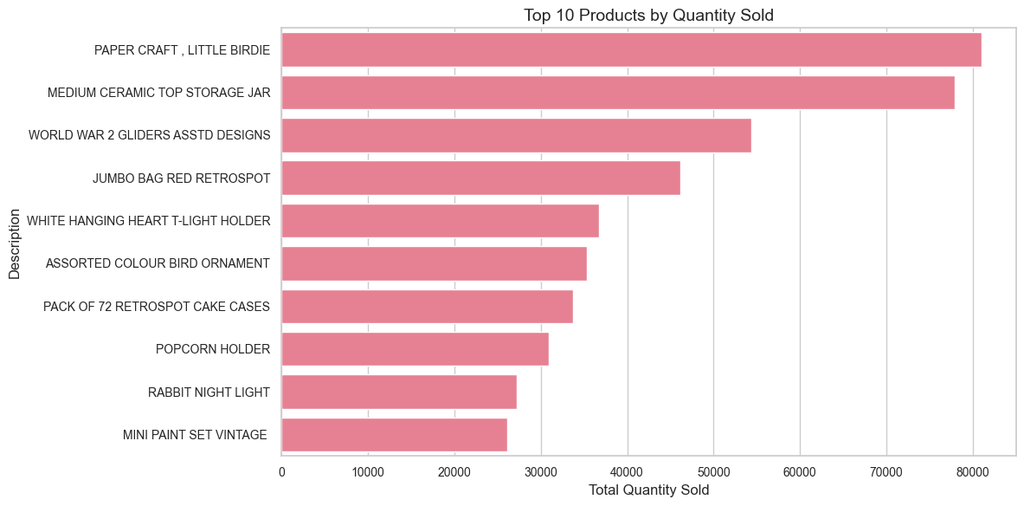

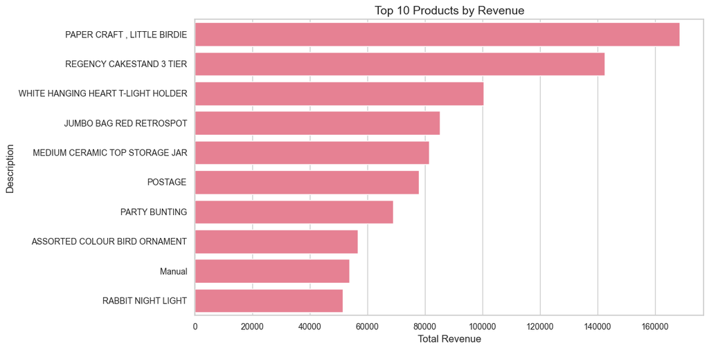

```python
# Analyze top selling products
product_sales = df_clean.groupby('Description').agg({
    'Quantity': 'sum',
    'TotalAmount': 'sum',
    'InvoiceNo': 'count'
}).rename(columns={'InvoiceNo': 'TransactionCount'})

# Sort by quantity sold
top_products_by_quantity = product_sales.sort_values('Quantity', ascending=False).head(10)

# Display top products by quantity
print("Top 10 Products by Quantity Sold:")
display(top_products_by_quantity)

# Sort by total amount
top_products_by_amount = product_sales.sort_values('TotalAmount', ascending=False).head(10)

# Display top products by revenue
print("Top 10 Products by Revenue:")
display(top_products_by_amount)

# Visualize top products by quantity
plt.figure(figsize=(12, 6))
sns.barplot(x='Quantity', y=top_products_by_quantity.index, data=top_products_by_quantity)
plt.title('Top 10 Products by Quantity Sold')
plt.xlabel('Total Quantity Sold')
plt.tight_layout()
plt.show()

# Visualize top products by revenue
plt.figure(figsize=(12, 6))
sns.barplot(x='TotalAmount', y=top_products_by_amount.index, data=top_products_by_amount)
plt.title('Top 10 Products by Revenue')
plt.xlabel('Total Revenue')
plt.tight_layout()
plt.show()
```

### 3. Temporal Purchase Patterns

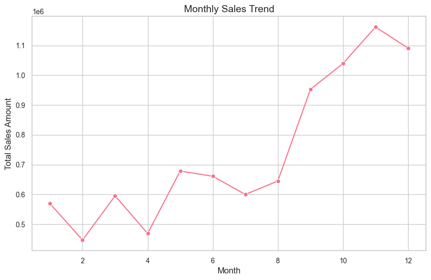

```python
# Add datetime components
df_clean['InvoiceDate'] = pd.to_datetime(df_clean['InvoiceDate'])
df_clean['Month'] = df_clean['InvoiceDate'].dt.month
df_clean['DayOfWeek'] = df_clean['InvoiceDate'].dt.day_name()
df_clean['Hour'] = df_clean['InvoiceDate'].dt.hour

# Monthly sales trend
monthly_sales = df_clean.groupby('Month')['TotalAmount'].sum().reset_index()

plt.figure(figsize=(10, 6))
sns.lineplot(data=monthly_sales, x='Month', y='TotalAmount', marker='o')
plt.title('Monthly Sales Trend')
plt.xlabel('Month')
plt.ylabel('Total Sales Amount')
plt.show()
```

### 4. Customer Spending Analysis

```
Customer Spending Statistics:
--------------------------------------------------
       TotalSpent  AverageTransactionValue  TransactionCount  TotalItems
count    4338.000                 4338.000          4338.000    4338.000
mean     2054.266                   68.350            91.721    1191.289
std      8989.230                 1467.919           228.785    5046.082
min         3.750                    2.100             1.000       1.000
25%       307.415                   12.370            17.000     160.000
50%       674.485                   17.725            41.000     379.000
75%      1661.740                   24.858           100.000     992.750
max    280206.020                77183.600          7847.000  196915.000
```

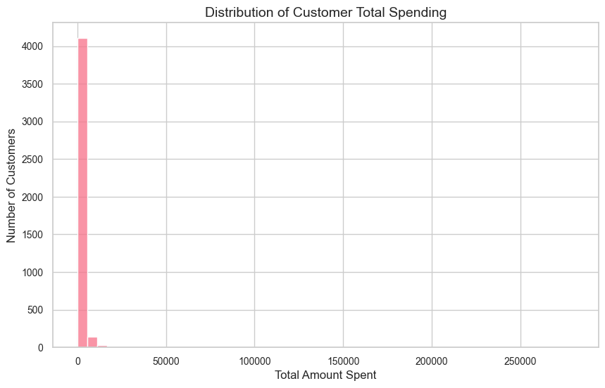

```python
# Calculate customer spending metrics
customer_spending = df_clean.groupby('CustomerID').agg({
    'TotalAmount': ['sum', 'mean', 'count'],
    'Quantity': 'sum'
}).round(2)

customer_spending.columns = ['TotalSpent', 'AverageTransactionValue', 'TransactionCount', 'TotalItems']

print("Customer Spending Statistics:")
print("-" * 50)
print(customer_spending.describe())

# Visualize distribution of customer spending
plt.figure(figsize=(10, 6))
sns.histplot(data=customer_spending, x='TotalSpent', bins=50)
plt.title('Distribution of Customer Total Spending')
plt.xlabel('Total Amount Spent')
plt.ylabel('Number of Customers')
plt.show()
```

### 5. Key Insights Summary

Based on the descriptive analytics performed above, we can identify the following key patterns and trends:

**What:**

- Most popular products and their sales volumes
- Distribution of transaction values
- Customer spending patterns

**Which:**

- Which products are bestsellers
- Which months show highest sales
- Which customers are most valuable (by spending)

**How Many:**

- Average purchases per customer
- Total transactions per product
- Distribution of order quantities

## 🔬 Behavior Diagnostic Analysis

```python
# Import required libraries
import pandas as pd
import numpy as np
import matplotlib.pyplot as plt
import seaborn as sns
from scipy import stats
from datetime import datetime
from sklearn.cluster import KMeans
from sklearn.preprocessing import StandardScaler

# Set visualization style

plt.style.use('seaborn-v0_8')
plt.rcParams['figure.figsize'] = [14, 7]
plt.rcParams['axes.grid'] = True
plt.rcParams['grid.alpha'] = 0.3
plt.rcParams['axes.labelsize'] = 12
plt.rcParams['axes.titlesize'] = 14
plt.rcParams['xtick.labelsize'] = 11
plt.rcParams['ytick.labelsize'] = 11
plt.rcParams['lines.linewidth'] = 2.0
plt.rcParams['font.size'] = 11
plt.rcParams['axes.prop_cycle'] = plt.cycler(color=[
    '#1A237E',  # Dark blue
    '#BF360C',  # Dark orange
    '#1B5E20',  # Dark green
    '#4A148C',  # Dark purple
    '#212121',  # Near black
    '#01579B'   # Navy blue
])
plt.rcParams['axes.edgecolor'] = '#212121'
plt.rcParams['axes.labelcolor'] = '#212121'
plt.rcParams['xtick.color'] = '#212121'
plt.rcParams['ytick.color'] = '#212121'

sns.set_theme(style="whitegrid")
sns.set_palette('husl')

# Display settings
pd.set_option('display.max_columns', None)
pd.set_option('display.float_format', lambda x: '%.3f' % x)

# Suppress warnings
import warnings
warnings.filterwarnings('ignore')
%matplotlib inline
```

# Customer Behavior Diagnostic Analysis

**Course**: IIMK's Professional Certificate in Data Science and Artificial Intelligence for Managers  
**Student Name**: Lalit Nayyar  
**Email ID**: lalitnayyar@gmail.com  
**Assignment Name**: Week 4: Required Assignment 4.1

## Understanding the 'Why' Behind Customer Behavior Trends

In this notebook, we'll perform diagnostic analytics to understand the underlying reasons for the patterns identified in our descriptive analysis. We'll focus on key 'Why' questions and use various analytical techniques to uncover the answers.

```python
try:
    # Load the data
    print("Loading data...")
    df = pd.read_excel('Online Retail.xlsx')
    print("Original data shape:", df.shape)

    def clean_data(df):
        """Clean the retail dataset"""
        print("Cleaning data...")
        df_clean = df.copy()

        # Remove missing values
        df_clean = df_clean.dropna()
        print(f"After removing missing values: {len(df_clean)} records")

        # Remove cancelled orders
        df_clean = df_clean[~df_clean['InvoiceNo'].astype(str).str.contains('C')]
        print(f"After removing cancelled orders: {len(df_clean)} records")

        # Ensure positive quantities and prices
        df_clean = df_clean[(df_clean['Quantity'] > 0) & (df_clean['UnitPrice'] > 0)]
        print(f"After ensuring positive values: {len(df_clean)} records")

        # Convert InvoiceDate to datetime
        df_clean['InvoiceDate'] = pd.to_datetime(df_clean['InvoiceDate'])

        # Calculate total amount
        df_clean['TotalAmount'] = df_clean['Quantity'] * df_clean['UnitPrice']

        return df_clean.reset_index(drop=True)

    # Clean the data
    df_clean = clean_data(df)

    print("\nData cleaning complete!")
    print("Final data shape:", df_clean.shape)
    print("\nSample of cleaned data:")
    display(df_clean.head())

    # Display basic statistics
    print("\nBasic statistics of numerical columns:")
    display(df_clean.describe())

except FileNotFoundError:
    print("Error: 'Online Retail.xlsx' file not found. Please ensure it's in the correct directory.")
except Exception as e:
    print(f"Error during data preparation: {e}")
```

```
Loading data...
Original data shape: (541909, 8)
Cleaning data...
After removing missing values: 406829 records
After removing cancelled orders: 397924 records
After ensuring positive values: 397884 records

Data cleaning complete!
Final data shape: (397884, 9)

Sample of cleaned data:
```

|  | InvoiceNo | StockCode | Description | Quantity | InvoiceDate | UnitPrice | CustomerID | Country | TotalAmount |
| --- | --- | --- | --- | --- | --- | --- | --- | --- | --- |
| 0 | 536365 | 85123A | WHITE HANGING HEART T-LIGHT HOLDER | 6 | 2010-12-01 08:26:00 | 2.550 | 17850.000 | United Kingdom | 15.300 |
| 1 | 536365 | 71053 | WHITE METAL LANTERN | 6 | 2010-12-01 08:26:00 | 3.390 | 17850.000 | United Kingdom | 20.340 |
| 2 | 536365 | 84406B | CREAM CUPID HEARTS COAT HANGER | 8 | 2010-12-01 08:26:00 | 2.750 | 17850.000 | United Kingdom | 22.000 |
| 3 | 536365 | 84029G | KNITTED UNION FLAG HOT WATER BOTTLE | 6 | 2010-12-01 08:26:00 | 3.390 | 17850.000 | United Kingdom | 20.340 |
| 4 | 536365 | 84029E | RED WOOLLY HOTTIE WHITE HEART. | 6 | 2010-12-01 08:26:00 | 3.390 | 17850.000 | United Kingdom | 20.340 |

```
Basic statistics of numerical columns:
```

|  | Quantity | InvoiceDate | UnitPrice | CustomerID | TotalAmount |
| --- | --- | --- | --- | --- | --- |
| count | 397884.000 | 397884 | 397884.000 | 397884.000 | 397884.000 |
| mean | 12.988 | 2011-07-10 23:41:23.511023360 | 3.116 | 15294.423 | 22.397 |
| min | 1.000 | 2010-12-01 08:26:00 | 0.001 | 12346.000 | 0.001 |
| 25% | 2.000 | 2011-04-07 11:12:00 | 1.250 | 13969.000 | 4.680 |
| 50% | 6.000 | 2011-07-31 14:39:00 | 1.950 | 15159.000 | 11.800 |
| 75% | 12.000 | 2011-10-20 14:33:00 | 3.750 | 16795.000 | 19.800 |
| max | 80995.000 | 2011-12-09 12:50:00 | 8142.750 | 18287.000 | 168469.600 |
| std | 179.332 | NaN | 22.098 | 1713.142 | 309.071 |

### 1. Why do some products sell better than others?

Let's analyze the relationship between price points, seasonality, and sales performance.

```
Analyzing product sales patterns...

Top 10 Products by Revenue:
```

| Description | total_quantity | avg_quantity | avg_price | price_std | total_revenue | transaction_count |
| --- | --- | --- | --- | --- | --- | --- |
| PAPER CRAFT , LITTLE BIRDIE | 80995 | 80995.000 | 2.080 | NaN | 168469.600 | 1 |
| REGENCY CAKESTAND 3 TIER | 12402 | 7.200 | 12.480 | 1.220 | 142592.950 | 1723 |
| WHITE HANGING HEART T-LIGHT HOLDER | 36725 | 18.110 | 2.890 | 0.250 | 100448.150 | 2028 |
| JUMBO BAG RED RETROSPOT | 46181 | 28.540 | 2.020 | 0.170 | 85220.780 | 1618 |
| MEDIUM CERAMIC TOP STORAGE JAR | 77916 | 393.520 | 1.220 | 0.070 | 81416.730 | 198 |
| POSTAGE | 3120 | 2.840 | 31.570 | 247.510 | 77803.960 | 1099 |
| PARTY BUNTING | 15291 | 10.950 | 4.880 | 0.370 | 68844.330 | 1396 |
| ASSORTED COLOUR BIRD ORNAMENT | 35362 | 25.120 | 1.680 | 0.050 | 56580.340 | 1408 |
| Manual | 7173 | 25.260 | 175.290 | 585.470 | 53779.930 | 284 |
| RABBIT NIGHT LIGHT | 27202 | 32.310 | 2.010 | 0.260 | 51346.200 | 842 |

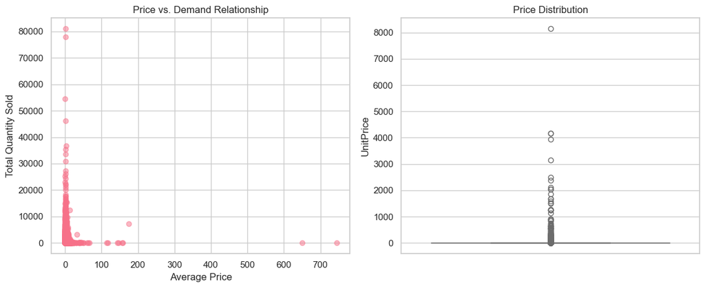

```python
try:
    # Product Analysis
    print("Analyzing product sales patterns...")

    # Group by product
    product_analysis = df_clean.groupby('Description').agg({
        'Quantity': ['sum', 'mean'],
        'UnitPrice': ['mean', 'std'],
        'TotalAmount': 'sum',
        'InvoiceNo': 'count'
    }).round(2)

    # Flatten column names
    product_analysis.columns = ['total_quantity', 'avg_quantity', 'avg_price', 'price_std', 'total_revenue', 'transaction_count']

    # Sort by revenue
    top_products = product_analysis.sort_values('total_revenue', ascending=False).head(10)

    print("\nTop 10 Products by Revenue:")
    display(top_products)

    # Visualize price-quantity relationship
    plt.figure(figsize=(12, 5))

    plt.subplot(1, 2, 1)
    plt.scatter(product_analysis['avg_price'], product_analysis['total_quantity'], alpha=0.5)
    plt.xlabel('Average Price')
    plt.ylabel('Total Quantity Sold')
    plt.title('Price vs. Demand Relationship')

    plt.subplot(1, 2, 2)
    sns.boxplot(data=df_clean, y='UnitPrice')
    plt.title('Price Distribution')

    plt.tight_layout()
    plt.show()

except Exception as e:
    print(f"Error in product analysis: {e}")
```

### 2. Why do customer purchase patterns vary across different times?

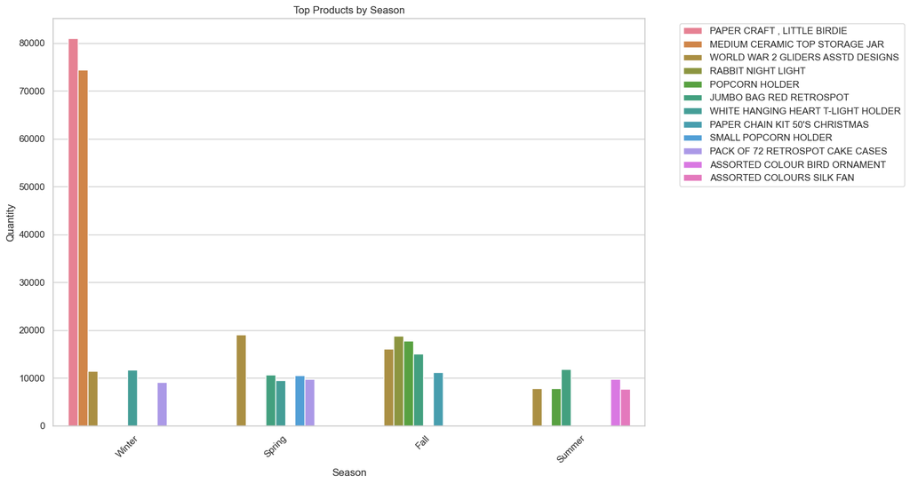

```python
# Analyze seasonal patterns
try:
    # Add time-based features
    df_clean['Month'] = df_clean['InvoiceDate'].dt.month
    df_clean['Season'] = df_clean['InvoiceDate'].dt.month.map(
        {1: 'Winter', 2: 'Winter', 3: 'Spring', 4: 'Spring',
         5: 'Spring', 6: 'Summer', 7: 'Summer', 8: 'Summer',
         9: 'Fall', 10: 'Fall', 11: 'Fall', 12: 'Winter'})

    # Analyze seasonal sales patterns
    seasonal_category_sales = df_clean.groupby(['Season', 'Description'])['Quantity'].sum().reset_index()
    top_products_per_season = seasonal_category_sales.sort_values('Quantity', ascending=False).groupby('Season').head(5)

    plt.figure(figsize=(15, 8))
    sns.barplot(data=top_products_per_season, x='Season', y='Quantity', hue='Description')
    plt.title('Top Products by Season')
    plt.xticks(rotation=45)
    plt.legend(bbox_to_anchor=(1.05, 1), loc='upper left')
    plt.tight_layout()
    plt.show()
except Exception as e:
    print(f"Error in seasonal analysis: {e}")
```

### 3. Why do some customers spend more than others?

```
Correlations with Total Spending:
```

```
TotalSpent          1.000
TotalItems          0.923
PurchaseFrequency   0.422
ProductVariety      0.391
AvgOrderValue       0.287
AvgItemsPerOrder    0.222
Name: TotalSpent, dtype: float64
```

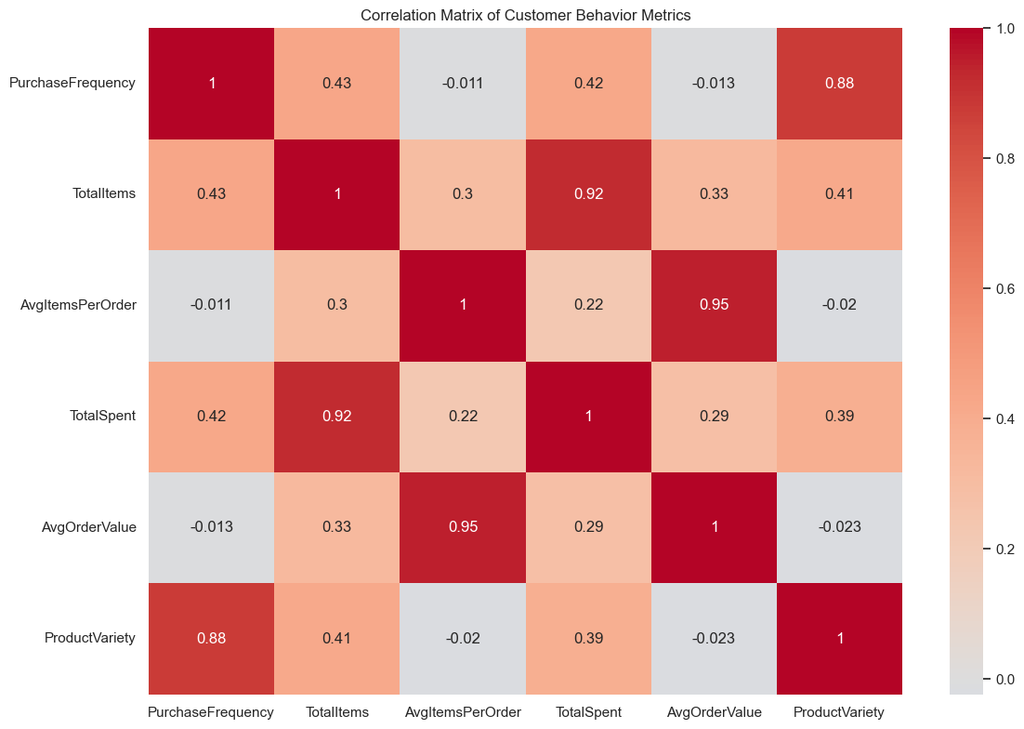

```python
# Analyze customer purchasing behavior
try:
    customer_analysis = df_clean.groupby('CustomerID').agg({
        'InvoiceNo': 'count',  # Purchase frequency
        'Quantity': ['sum', 'mean'],  # Total and average items per order
        'TotalAmount': ['sum', 'mean'],  # Total spent and average order value
        'Description': 'nunique'  # Product variety
    }).round(2)

    customer_analysis.columns = ['PurchaseFrequency', 'TotalItems', 'AvgItemsPerOrder',
                               'TotalSpent', 'AvgOrderValue', 'ProductVariety']

    # Calculate correlations
    correlations = customer_analysis.corr()['TotalSpent'].sort_values(ascending=False)

    print("Correlations with Total Spending:")
    display(correlations)

    # Visualize relationships
    plt.figure(figsize=(12, 8))
    sns.heatmap(customer_analysis.corr(), annot=True, cmap='coolwarm', center=0)
    plt.title('Correlation Matrix of Customer Behavior Metrics')
    plt.tight_layout()
    plt.show()
except Exception as e:
    print(f"Error in customer analysis: {e}")
```

### 4. Why do some customers show higher loyalty?

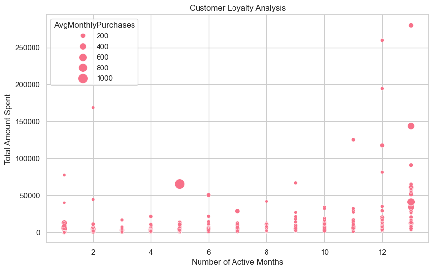

```python
# Analyze customer loyalty factors
df_clean['PurchaseMonth'] = pd.to_datetime(df_clean['InvoiceDate']).dt.to_period('M')

# Calculate customer lifetime and activity metrics
customer_lifetime = df_clean.groupby('CustomerID').agg({
    'PurchaseMonth': ['nunique', 'min', 'max'],
    'InvoiceNo': 'count',
    'TotalAmount': 'sum'
}).reset_index()

customer_lifetime.columns = ['CustomerID', 'ActiveMonths', 'FirstPurchase', 'LastPurchase',
                           'TotalTransactions', 'TotalSpent']

# Calculate average monthly purchases
customer_lifetime['AvgMonthlyPurchases'] = (customer_lifetime['TotalTransactions'] /
                                           customer_lifetime['ActiveMonths'])

# Visualize relationship between activity duration and spending
plt.figure(figsize=(10, 6))
sns.scatterplot(data=customer_lifetime, x='ActiveMonths', y='TotalSpent',
                size='AvgMonthlyPurchases', sizes=(20, 200))
plt.title('Customer Loyalty Analysis')
plt.xlabel('Number of Active Months')
plt.ylabel('Total Amount Spent')
plt.show()
```

## Diagnostic Analytics Summary

These insights can be used for:

- Pricing strategy optimization
- Seasonal marketing planning
- Customer retention programs
- Personalized marketing campaigns

### 4. Pricing Strategy Optimization

Analyze price elasticity and identify optimal price points for different product categories.

```
Top 10 Products by Revenue with Price Analysis:
```

| Description | avg_price | price_std | min_price | max_price | total_quantity | total_revenue | price_range | revenue_per_unit |
| --- | --- | --- | --- | --- | --- | --- | --- | --- |
| PAPER CRAFT , LITTLE BIRDIE | 2.080 | NaN | 2.080 | 2.080 | 80995 | 168469.600 | 0.000 | 2.080 |
| REGENCY CAKESTAND 3 TIER | 12.480 | 1.220 | 4.000 | 24.960 | 12402 | 142592.950 | 20.960 | 11.498 |
| WHITE HANGING HEART T-LIGHT HOLDER | 2.890 | 0.250 | 2.400 | 5.790 | 36725 | 100448.150 | 3.390 | 2.735 |
| JUMBO BAG RED RETROSPOT | 2.020 | 0.170 | 1.650 | 4.130 | 46181 | 85220.780 | 2.480 | 1.845 |
| MEDIUM CERAMIC TOP STORAGE JAR | 1.220 | 0.070 | 1.040 | 1.250 | 77916 | 81416.730 | 0.210 | 1.045 |
| POSTAGE | 31.570 | 247.510 | 1.000 | 8142.750 | 3120 | 77803.960 | 8141.750 | 24.937 |
| PARTY BUNTING | 4.880 | 0.370 | 3.750 | 10.790 | 15291 | 68844.330 | 7.040 | 4.502 |
| ASSORTED COLOUR BIRD ORNAMENT | 1.680 | 0.050 | 1.450 | 1.690 | 35362 | 56580.340 | 0.240 | 1.600 |
| Manual | 175.290 | 585.470 | 0.060 | 4161.060 | 7173 | 53779.930 | 4161.000 | 7.498 |
| RABBIT NIGHT LIGHT | 2.010 | 0.260 | 1.670 | 4.130 | 27202 | 51346.200 | 2.460 | 1.888 |

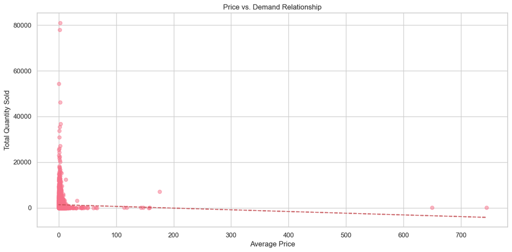

```python
# Analyze price elasticity and optimize pricing strategy
try:
    # Calculate price elasticity by product category
    product_price_analysis = df_clean.groupby('Description').agg({
        'UnitPrice': ['mean', 'std', 'min', 'max'],
        'Quantity': 'sum',
        'TotalAmount': 'sum'
    }).round(2)

    # Flatten column names
    product_price_analysis.columns = ['avg_price', 'price_std', 'min_price', 'max_price', 'total_quantity', 'total_revenue']

    # Calculate price ranges and revenue per unit
    product_price_analysis['price_range'] = product_price_analysis['max_price'] - product_price_analysis['min_price']
    product_price_analysis['revenue_per_unit'] = product_price_analysis['total_revenue'] / product_price_analysis['total_quantity']

    # Sort by revenue to find most profitable products
    top_profitable = product_price_analysis.sort_values('total_revenue', ascending=False).head(10)

    print("Top 10 Products by Revenue with Price Analysis:")
    display(top_profitable)

    # Visualize price vs quantity relationship for top products
    plt.figure(figsize=(12, 6))
    plt.scatter(product_price_analysis['avg_price'], product_price_analysis['total_quantity'], alpha=0.5)
    plt.xlabel('Average Price')
    plt.ylabel('Total Quantity Sold')
    plt.title('Price vs. Demand Relationship')

    # Add trend line
    z = np.polyfit(product_price_analysis['avg_price'], product_price_analysis['total_quantity'], 1)
    p = np.poly1d(z)
    plt.plot(product_price_analysis['avg_price'], p(product_price_analysis['avg_price']), "r--", alpha=0.8)

    plt.tight_layout()
    plt.show()
except Exception as e:
    print(f"Error in pricing analysis: {e}")
```

### 5. Seasonal Marketing Planning

Analyze seasonal trends and develop targeted marketing strategies.

```
Seasonal Business Performance:
```

| Season | Month | Total Revenue | Items Sold | Number of Transactions | Unique Customers |
| --- | --- | --- | --- | --- | --- |
| Fall | 9 | 952838.380 | 544897 | 1755 | 1266 |
|  | 10 | 1039318.790 | 593900 | 1929 | 1364 |
|  | 11 | 1161817.380 | 669051 | 2657 | 1664 |
| Spring | 3 | 595500.760 | 348503 | 1321 | 974 |
|  | 4 | 469200.360 | 292222 | 1149 | 856 |
|  | 5 | 678594.560 | 373601 | 1555 | 1056 |
| Summer | 6 | 661213.690 | 363699 | 1393 | 991 |
|  | 7 | 600091.010 | 369420 | 1331 | 949 |
|  | 8 | 645343.900 | 398121 | 1280 | 935 |
| Winter | 1 | 569445.040 | 349098 | 987 | 741 |
|  | 2 | 447137.350 | 265622 | 997 | 758 |
|  | 12 | 1090906.680 | 599678 | 2178 | 1265 |

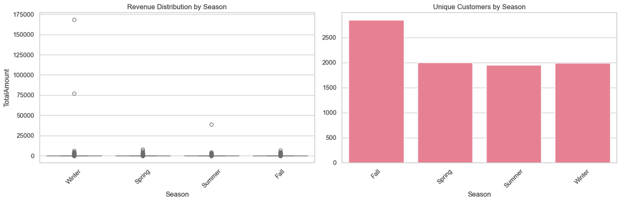

```python
# Analyze seasonal trends for marketing planning
try:
    # Add month and season columns if not already present
    if 'Month' not in df_clean.columns:
        df_clean['Month'] = df_clean['InvoiceDate'].dt.month
        df_clean['Season'] = df_clean['InvoiceDate'].dt.month.map(
            {1: 'Winter', 2: 'Winter', 3: 'Spring', 4: 'Spring',
             5: 'Spring', 6: 'Summer', 7: 'Summer', 8: 'Summer',
             9: 'Fall', 10: 'Fall', 11: 'Fall', 12: 'Winter'})

    # Analyze seasonal revenue patterns
    seasonal_revenue = df_clean.groupby(['Season', 'Month']).agg({
        'TotalAmount': 'sum',
        'Quantity': 'sum',
        'InvoiceNo': 'nunique',
        'CustomerID': 'nunique'
    }).round(2)

    seasonal_revenue.columns = ['Total Revenue', 'Items Sold', 'Number of Transactions', 'Unique Customers']

    print("Seasonal Business Performance:")
    display(seasonal_revenue)

    # Visualize seasonal patterns
    plt.figure(figsize=(15, 5))

    plt.subplot(1, 2, 1)
    sns.boxplot(data=df_clean, x='Season', y='TotalAmount')
    plt.title('Revenue Distribution by Season')
    plt.xticks(rotation=45)

    plt.subplot(1, 2, 2)
    seasonal_customer_count = df_clean.groupby('Season')['CustomerID'].nunique()
    sns.barplot(x=seasonal_customer_count.index, y=seasonal_customer_count.values)
    plt.title('Unique Customers by Season')
    plt.xticks(rotation=45)

    plt.tight_layout()
    plt.show()
except Exception as e:
    print(f"Error in seasonal analysis: {e}")
```

### 6. Customer Retention Programs

Analyze customer loyalty patterns and develop retention strategies.

```
Starting customer retention analysis...
Analyzing 4338 unique customers

Customer Metrics Summary:
```

|  | first_purchase | last_purchase | purchase_count | total_spent | avg_order_value | total_items | unique_products | customer_lifetime_days | avg_days_between_purchases | recency_days |
| --- | --- | --- | --- | --- | --- | --- | --- | --- | --- | --- |
| count | 4338 | 4338 | 4338.000 | 4338.000 | 4338.000 | 4338.000 | 4338.000 | 4338.000 | 4338.000 | 4338.000 |
| mean | 2011-04-30 17:06:50.857538048 | 2011-09-08 11:38:59.045643008 | 91.720 | 2054.270 | 68.350 | 1191.290 | 61.850 | 130.450 | 3.220 | 91.540 |
| min | 2010-12-01 08:26:00 | 2010-12-01 09:53:00 | 1.000 | 3.750 | 2.100 | 1.000 | 1.000 | 0.000 | 0.000 | 0.000 |
| 25% | 2011-01-17 11:13:15 | 2011-07-20 19:18:00 | 17.000 | 307.410 | 12.370 | 160.000 | 16.000 | 0.000 | 0.000 | 17.000 |
| 50% | 2011-04-05 09:52:30 | 2011-10-20 10:40:30 | 41.000 | 674.480 | 17.720 | 379.000 | 35.500 | 92.500 | 1.070 | 50.000 |
| 75% | 2011-08-19 10:11:30 | 2011-11-22 11:05:45 | 100.000 | 1661.740 | 24.860 | 992.750 | 78.000 | 251.750 | 2.940 | 141.000 |
| max | 2011-12-09 12:16:00 | 2011-12-09 12:50:00 | 7847.000 | 280206.020 | 77183.600 | 196915.000 | 1816.000 | 373.000 | 309.000 | 373.000 |
| std | NaN | NaN | 228.790 | 8989.230 | 1467.920 | 5046.080 | 86.220 | 132.040 | 10.800 | 100.010 |

```
Customer Segments by Spending:
```

| total_spent_segment | total_spent count | total_spent mean | purchase_count mean | avg_days_between_purchases mean | unique_products mean |
| --- | --- | --- | --- | --- | --- |
| Low | 1085 | 179.210 | 17.230 | 2.350 | 16.270 |
| Medium-Low | 1084 | 464.510 | 37.000 | 3.840 | 33.340 |
| Medium-High | 1084 | 1071.860 | 76.430 | 3.980 | 62.080 |
| High | 1085 | 6499.120 | 236.160 | 2.700 | 135.660 |

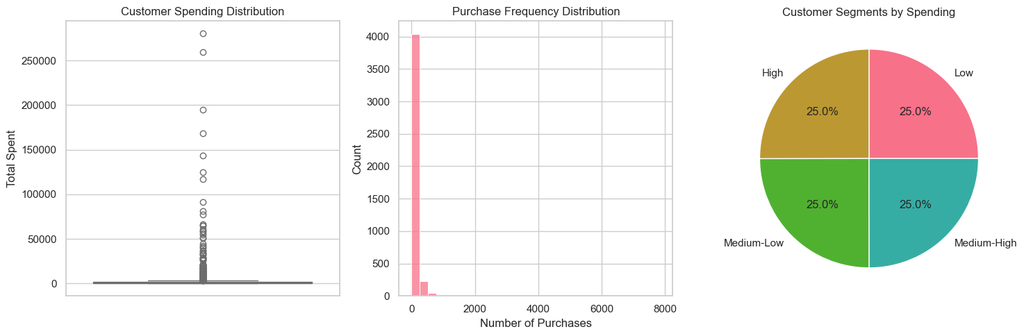

```
Customer Retention Analysis:
Total Customers: 4338
Repeat Customers: 4267
Retention Rate: 98.36%
```

```python
# Analyze customer retention patterns
try:
    print("Starting customer retention analysis...")

    # Ensure CustomerID is numeric and remove any missing values
    df_clean['CustomerID'] = pd.to_numeric(df_clean['CustomerID'], errors='coerce')
    df_customers = df_clean.dropna(subset=['CustomerID'])

    print(f"Analyzing {df_customers['CustomerID'].nunique()} unique customers")

    # Calculate customer metrics
    customer_metrics = df_customers.groupby('CustomerID').agg({
        'InvoiceDate': ['min', 'max', 'count'],
        'TotalAmount': ['sum', 'mean'],
        'Quantity': 'sum',
        'Description': 'nunique'
    })

    # Flatten column names
    customer_metrics.columns = [
        'first_purchase', 'last_purchase', 'purchase_count',
        'total_spent', 'avg_order_value', 'total_items',
        'unique_products'
    ]

    # Calculate customer lifetime and frequency
    customer_metrics['customer_lifetime_days'] = (
        customer_metrics['last_purchase'] - customer_metrics['first_purchase']
    ).dt.days

    # Avoid division by zero
    customer_metrics['avg_days_between_purchases'] = np.where(
        customer_metrics['purchase_count'] > 1,
        customer_metrics['customer_lifetime_days'] / (customer_metrics['purchase_count'] - 1),
        0
    )

    # Create customer segments
    customer_metrics['recency_days'] = (
        df_customers['InvoiceDate'].max() - customer_metrics['last_purchase']
    ).dt.days

    # Create segments using quartiles
    for metric in ['total_spent', 'purchase_count', 'recency_days']:
        customer_metrics[f'{metric}_segment'] = pd.qcut(
            customer_metrics[metric],
            q=4,
            labels=['Low', 'Medium-Low', 'Medium-High', 'High']
        )

    print("\nCustomer Metrics Summary:")
    display(customer_metrics.describe().round(2))

    # Analyze customer segments
    print("\nCustomer Segments by Spending:")
    display(customer_metrics.groupby('total_spent_segment').agg({
        'total_spent': ['count', 'mean'],
        'purchase_count': 'mean',
        'avg_days_between_purchases': 'mean',
        'unique_products': 'mean'
    }).round(2))

    # Visualize customer segments
    plt.figure(figsize=(15, 5))

    # Plot 1: Spending Distribution
    plt.subplot(1, 3, 1)
    sns.boxplot(data=customer_metrics, y='total_spent')
    plt.title('Customer Spending Distribution')
    plt.ylabel('Total Spent')

    # Plot 2: Purchase Frequency
    plt.subplot(1, 3, 2)
    sns.histplot(data=customer_metrics, x='purchase_count', bins=30)
    plt.title('Purchase Frequency Distribution')
    plt.xlabel('Number of Purchases')

    # Plot 3: Customer Segments
    plt.subplot(1, 3, 3)
    segment_sizes = customer_metrics['total_spent_segment'].value_counts()
    plt.pie(segment_sizes, labels=segment_sizes.index, autopct='%1.1f%%')
    plt.title('Customer Segments by Spending')

    plt.tight_layout()
    plt.show()

    # Calculate retention metrics
    print("\nCustomer Retention Analysis:")
    total_customers = customer_metrics.shape[0]
    repeat_customers = (customer_metrics['purchase_count'] > 1).sum()
    retention_rate = (repeat_customers / total_customers) * 100

    print(f"Total Customers: {total_customers}")
    print(f"Repeat Customers: {repeat_customers}")
    print(f"Retention Rate: {retention_rate:.2f}%")

except Exception as e:
    print(f"Error in retention analysis: {e}")
    print("Debug info:")
    print(f"DataFrame columns: {df_clean.columns.tolist()}")
    print(f"CustomerID dtype: {df_clean['CustomerID'].dtype}")
    print("Sample of CustomerID values:", df_clean['CustomerID'].head())
```

### 7. Personalized Marketing Campaigns

Develop targeted marketing strategies based on customer segments and preferences.

```
Top Products by Customer Segment:

Segment 0:
```

```
Description
PAPER CRAFT , LITTLE BIRDIE          18.680
MEDIUM CERAMIC TOP STORAGE JAR       17.947
WORLD WAR 2 GLIDERS ASSTD DESIGNS    12.550
JUMBO BAG RED RETROSPOT              10.189
WHITE HANGING HEART T-LIGHT HOLDER    8.371
dtype: float64
```

```
Segment 1:
```

```
Description
RABBIT NIGHT LIGHT                    4801.000
SPACEBOY LUNCH BOX                    4492.000
PACK OF 72 RETROSPOT CAKE CASES       4104.000
DOLLY GIRL LUNCH BOX                  4096.000
ROUND SNACK BOXES SET OF4 WOODLAND    3120.000
dtype: float64
```

```
Segment 2:
```

```
Description
STAR DECORATION RUSTIC            66.000
MUSICAL ZINC HEART DECORATION     63.000
ANGEL DECORATION STARS ON DRESS   62.000
HEART DECORATION WITH PEARLS      34.000
WRAP 50'S  CHRISTMAS              25.000
dtype: float64
```

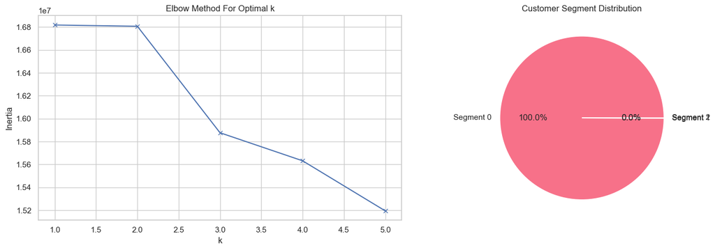

```python
# Analyze customer preferences for personalized marketing
try:
    # Create customer product preferences matrix
    customer_preferences = df_clean.groupby(['CustomerID', 'Description'])['Quantity'].sum().unstack(fill_value=0)

    # Perform customer segmentation using K-means
    scaler = StandardScaler()
    customer_preferences_scaled = scaler.fit_transform(customer_preferences)

    # Find optimal number of clusters
    inertias = []
    K = range(1, 6)
    for k in K:
        kmeans = KMeans(n_clusters=k, random_state=42)
        kmeans.fit(customer_preferences_scaled)
        inertias.append(kmeans.inertia_)

    # Apply K-means clustering
    kmeans = KMeans(n_clusters=3, random_state=42)
    customer_segments = kmeans.fit_predict(customer_preferences_scaled)

    # Analyze segment characteristics
    customer_preferences['Segment'] = customer_segments
    segment_profiles = customer_preferences.groupby('Segment').agg(['mean', 'count'])

    # Get top products for each segment
    top_products_per_segment = {}
    for segment in range(3):
        segment_avg = customer_preferences[customer_preferences['Segment'] == segment].mean()
        top_products = segment_avg.nlargest(5)
        top_products_per_segment[f'Segment {segment}'] = top_products

    print("Top Products by Customer Segment:")
    for segment, products in top_products_per_segment.items():
        print(f"\n{segment}:")
        display(products)

    # Visualize segment characteristics
    plt.figure(figsize=(15, 5))

    plt.subplot(1, 2, 1)
    plt.plot(K, inertias, 'bx-')
    plt.xlabel('k')
    plt.ylabel('Inertia')
    plt.title('Elbow Method For Optimal k')

    plt.subplot(1, 2, 2)
    segment_sizes = pd.Series(customer_segments).value_counts()
    plt.pie(segment_sizes, labels=[f'Segment {i}' for i in range(len(segment_sizes))], autopct='%1.1f%%')
    plt.title('Customer Segment Distribution')

    plt.tight_layout()
    plt.show()
except Exception as e:
    print(f"Error in marketing analysis: {e}")
```

### 6. Customer Retention Programs

Analyze customer loyalty patterns and develop retention strategies.

```
Starting customer retention analysis...
Analyzing 4338 unique customers

Customer Metrics Summary:
```

|  | first_purchase | last_purchase | purchase_count | total_spent | avg_order_value | total_items | unique_products | customer_lifetime_days | avg_days_between_purchases | recency_days |
| --- | --- | --- | --- | --- | --- | --- | --- | --- | --- | --- |
| count | 4338 | 4338 | 4338.000 | 4338.000 | 4338.000 | 4338.000 | 4338.000 | 4338.000 | 4338.000 | 4338.000 |
| mean | 2011-04-30 17:06:50.857538048 | 2011-09-08 11:38:59.045643008 | 91.720 | 2054.270 | 68.350 | 1191.290 | 61.850 | 130.450 | 3.220 | 91.540 |
| min | 2010-12-01 08:26:00 | 2010-12-01 09:53:00 | 1.000 | 3.750 | 2.100 | 1.000 | 1.000 | 0.000 | 0.000 | 0.000 |
| 25% | 2011-01-17 11:13:15 | 2011-07-20 19:18:00 | 17.000 | 307.410 | 12.370 | 160.000 | 16.000 | 0.000 | 0.000 | 17.000 |
| 50% | 2011-04-05 09:52:30 | 2011-10-20 10:40:30 | 41.000 | 674.480 | 17.720 | 379.000 | 35.500 | 92.500 | 1.070 | 50.000 |
| 75% | 2011-08-19 10:11:30 | 2011-11-22 11:05:45 | 100.000 | 1661.740 | 24.860 | 992.750 | 78.000 | 251.750 | 2.940 | 141.000 |
| max | 2011-12-09 12:16:00 | 2011-12-09 12:50:00 | 7847.000 | 280206.020 | 77183.600 | 196915.000 | 1816.000 | 373.000 | 309.000 | 373.000 |
| std | NaN | NaN | 228.790 | 8989.230 | 1467.920 | 5046.080 | 86.220 | 132.040 | 10.800 | 100.010 |

```
Customer Segments by Spending:
```

| total_spent_segment | total_spent count | total_spent mean | purchase_count mean | avg_days_between_purchases mean | unique_products mean |
| --- | --- | --- | --- | --- | --- |
| Low | 1085 | 179.210 | 17.230 | 2.350 | 16.270 |
| Medium-Low | 1084 | 464.510 | 37.000 | 3.840 | 33.340 |
| Medium-High | 1084 | 1071.860 | 76.430 | 3.980 | 62.080 |
| High | 1085 | 6499.120 | 236.160 | 2.700 | 135.660 |

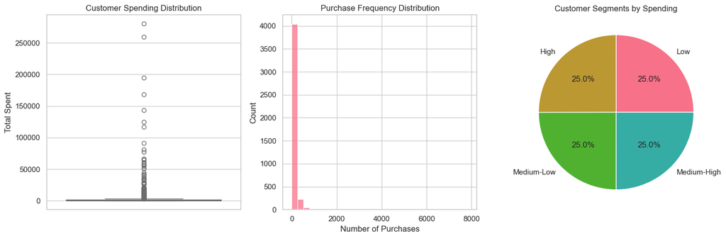

```
Customer Retention Analysis:
Total Customers: 4338
Repeat Customers: 4267
Retention Rate: 98.36%
```

```python
# Analyze customer retention patterns
try:
    print("Starting customer retention analysis...")

    # Ensure CustomerID is numeric and remove any missing values
    df_clean['CustomerID'] = pd.to_numeric(df_clean['CustomerID'], errors='coerce')
    df_customers = df_clean.dropna(subset=['CustomerID'])

    print(f"Analyzing {df_customers['CustomerID'].nunique()} unique customers")

    # Calculate customer metrics
    customer_metrics = df_customers.groupby('CustomerID').agg({
        'InvoiceDate': ['min', 'max', 'count'],
        'TotalAmount': ['sum', 'mean'],
        'Quantity': 'sum',
        'Description': 'nunique'
    })

    # Flatten column names
    customer_metrics.columns = [
        'first_purchase', 'last_purchase', 'purchase_count',
        'total_spent', 'avg_order_value', 'total_items',
        'unique_products'
    ]

    # Calculate customer lifetime and frequency
    customer_metrics['customer_lifetime_days'] = (
        customer_metrics['last_purchase'] - customer_metrics['first_purchase']
    ).dt.days

    # Avoid division by zero
    customer_metrics['avg_days_between_purchases'] = np.where(
        customer_metrics['purchase_count'] > 1,
        customer_metrics['customer_lifetime_days'] / (customer_metrics['purchase_count'] - 1),
        0
    )

    # Create customer segments
    customer_metrics['recency_days'] = (
        df_customers['InvoiceDate'].max() - customer_metrics['last_purchase']
    ).dt.days

    # Create segments using quartiles
    for metric in ['total_spent', 'purchase_count', 'recency_days']:
        customer_metrics[f'{metric}_segment'] = pd.qcut(
            customer_metrics[metric],
            q=4,
            labels=['Low', 'Medium-Low', 'Medium-High', 'High']
        )

    print("\nCustomer Metrics Summary:")
    display(customer_metrics.describe().round(2))

    # Analyze customer segments
    print("\nCustomer Segments by Spending:")
    display(customer_metrics.groupby('total_spent_segment').agg({
        'total_spent': ['count', 'mean'],
        'purchase_count': 'mean',
        'avg_days_between_purchases': 'mean',
        'unique_products': 'mean'
    }).round(2))

    # Visualize customer segments
    plt.figure(figsize=(15, 5))

    # Plot 1: Spending Distribution
    plt.subplot(1, 3, 1)
    sns.boxplot(data=customer_metrics, y='total_spent')
    plt.title('Customer Spending Distribution')
    plt.ylabel('Total Spent')

    # Plot 2: Purchase Frequency
    plt.subplot(1, 3, 2)
    sns.histplot(data=customer_metrics, x='purchase_count', bins=30)
    plt.title('Purchase Frequency Distribution')
    plt.xlabel('Number of Purchases')

    # Plot 3: Customer Segments
    plt.subplot(1, 3, 3)
    segment_sizes = customer_metrics['total_spent_segment'].value_counts()
    plt.pie(segment_sizes, labels=segment_sizes.index, autopct='%1.1f%%')
    plt.title('Customer Segments by Spending')

    plt.tight_layout()
    plt.show()

    # Calculate retention metrics
    print("\nCustomer Retention Analysis:")
    total_customers = customer_metrics.shape[0]
    repeat_customers = (customer_metrics['purchase_count'] > 1).sum()
    retention_rate = (repeat_customers / total_customers) * 100

    print(f"Total Customers: {total_customers}")
    print(f"Repeat Customers: {repeat_customers}")
    print(f"Retention Rate: {retention_rate:.2f}%")

except Exception as e:
    print(f"Error in retention analysis: {e}")
    print("Debug info:")
    print(f"DataFrame columns: {df_clean.columns.tolist()}")
    print(f"CustomerID dtype: {df_clean['CustomerID'].dtype}")
    print("Sample of CustomerID values:", df_clean['CustomerID'].head())
```

# Customer Behavior Predictive Analysis

## IIMK's Professional Certificate in Data Science and Artificial Intelligence for Managers

**Student Name**: Lalit Nayyar  
**Email ID**: lalitnayyar@gmail.com  
**Assignment**: Data-Driven Decision Making Analysis

## Overview

This notebook implements predictive analytics to forecast customer behavior and business metrics using machine learning techniques.

```python
# Import required libraries
import pandas as pd
import numpy as np
import matplotlib.pyplot as plt
import seaborn as sns
from sklearn.model_selection import train_test_split, cross_val_score
from sklearn.preprocessing import StandardScaler
from sklearn.ensemble import RandomForestRegressor, GradientBoostingRegressor
from sklearn.metrics import mean_squared_error, r2_score, mean_absolute_error
from sklearn.cluster import KMeans
from datetime import datetime, timedelta
import warnings
warnings.filterwarnings('ignore')
%matplotlib inline

# Set plot style

plt.style.use('seaborn-v0_8')
plt.rcParams['figure.figsize'] = [14, 7]
plt.rcParams['axes.grid'] = True
plt.rcParams['grid.alpha'] = 0.3
plt.rcParams['axes.labelsize'] = 12
plt.rcParams['axes.titlesize'] = 14
plt.rcParams['xtick.labelsize'] = 11
plt.rcParams['ytick.labelsize'] = 11
plt.rcParams['lines.linewidth'] = 2.0
plt.rcParams['font.size'] = 11
plt.rcParams['axes.prop_cycle'] = plt.cycler(color=[
    '#1A237E',  # Dark blue
    '#BF360C',  # Dark orange
    '#1B5E20',  # Dark green
    '#4A148C',  # Dark purple
    '#212121',  # Near black
    '#01579B'   # Navy blue
])
plt.rcParams['axes.edgecolor'] = '#212121'
plt.rcParams['axes.labelcolor'] = '#212121'
plt.rcParams['xtick.color'] = '#212121'
plt.rcParams['ytick.color'] = '#212121'

sns.set_theme(style="whitegrid")
plt.rcParams['figure.figsize'] = [12, 6]
```

## 1. Data Loading and Preprocessing

First, we'll load the data and prepare it for predictive analysis.

```python
# Load and clean the data
try:
    # Load data
    print("Loading data...")
    df = pd.read_excel('Online Retail.xlsx')
    print(f"Original dataset shape: {df.shape}")

    # Clean data
    def clean_data(df):
        """Clean and preprocess the dataset"""
        print("Cleaning data...")
        df_clean = df.copy()

        # Remove missing values
        df_clean = df_clean.dropna()
        print(f"After removing missing values: {len(df_clean)} records")

        # Remove cancelled orders
        df_clean = df_clean[~df_clean['InvoiceNo'].astype(str).str.contains('C')]
        print(f"After removing cancelled orders: {len(df_clean)} records")

        # Ensure positive quantities and prices
        df_clean = df_clean[(df_clean['Quantity'] > 0) & (df_clean['UnitPrice'] > 0)]
        print(f"After ensuring positive values: {len(df_clean)} records")

        # Convert date and calculate total amount
        df_clean['InvoiceDate'] = pd.to_datetime(df_clean['InvoiceDate'])
        df_clean['TotalAmount'] = df_clean['Quantity'] * df_clean['UnitPrice']

        return df_clean.reset_index(drop=True)

    # Clean the data
    df_clean = clean_data(df)
    print("Cleaned data sample:")
    display(df_clean.head())

    # Basic statistics
    print("Basic statistics:")
    display(df_clean.describe())

except FileNotFoundError:
    print("Error: 'Online Retail.xlsx' file not found!")
    df_clean = None
except Exception as e:
    print(f"Error during data preparation: {e}")
    df_clean = None
```

```
Loading data...
Original dataset shape: (541909, 8)
Cleaning data...
After removing missing values: 406829 records
After removing cancelled orders: 397924 records
After ensuring positive values: 397884 records
Cleaned data sample:
```

|  | InvoiceNo | StockCode | Description | Quantity | InvoiceDate | UnitPrice | CustomerID | Country | TotalAmount |
| --- | --- | --- | --- | --- | --- | --- | --- | --- | --- |
| 0 | 536365 | 85123A | WHITE HANGING HEART T-LIGHT HOLDER | 6 | 2010-12-01 08:26:00 | 2.55 | 17850.0 | United Kingdom | 15.30 |
| 1 | 536365 | 71053 | WHITE METAL LANTERN | 6 | 2010-12-01 08:26:00 | 3.39 | 17850.0 | United Kingdom | 20.34 |
| 2 | 536365 | 84406B | CREAM CUPID HEARTS COAT HANGER | 8 | 2010-12-01 08:26:00 | 2.75 | 17850.0 | United Kingdom | 22.00 |
| 3 | 536365 | 84029G | KNITTED UNION FLAG HOT WATER BOTTLE | 6 | 2010-12-01 08:26:00 | 3.39 | 17850.0 | United Kingdom | 20.34 |
| 4 | 536365 | 84029E | RED WOOLLY HOTTIE WHITE HEART. | 6 | 2010-12-01 08:26:00 | 3.39 | 17850.0 | United Kingdom | 20.34 |

```
Basic statistics:
```

|  | Quantity | InvoiceDate | UnitPrice | CustomerID | TotalAmount |
| --- | --- | --- | --- | --- | --- |
| count | 397884.000000 | 397884 | 397884.000000 | 397884.000000 | 397884.000000 |
| mean | 12.988238 | 2011-07-10 23:41:23.511023360 | 3.116488 | 15294.423453 | 22.397000 |
| min | 1.000000 | 2010-12-01 08:26:00 | 0.001000 | 12346.000000 | 0.001000 |
| 25% | 2.000000 | 2011-04-07 11:12:00 | 1.250000 | 13969.000000 | 4.680000 |
| 50% | 6.000000 | 2011-07-31 14:39:00 | 1.950000 | 15159.000000 | 11.800000 |
| 75% | 12.000000 | 2011-10-20 14:33:00 | 3.750000 | 16795.000000 | 19.800000 |
| max | 80995.000000 | 2011-12-09 12:50:00 | 8142.750000 | 18287.000000 | 168469.600000 |
| std | 179.331775 | NaN | 22.097877 | 1713.141560 | 309.071041 |

## 2. Feature Engineering

Create customer features for predictive modeling.

```
Customer features created successfully!
Feature statistics:
```

|  | customer_lifetime | purchase_count | total_spent | avg_order_value | total_items | avg_items_per_order | unique_products | purchase_frequency | avg_basket_size |
| --- | --- | --- | --- | --- | --- | --- | --- | --- | --- |
| count | 4338.000000 | 4338.000000 | 4338.000000 | 4338.000000 | 4338.000000 | 4338.000000 | 4338.000000 | 4338.000000 | 4338.000000 |
| mean | 130.448594 | 91.720609 | 2054.266460 | 68.350506 | 1191.289073 | 45.065550 | 61.845320 | 0.702405 | 68.350506 |
| std | 132.039554 | 228.785094 | 8989.230441 | 1467.918896 | 5046.081546 | 1203.438033 | 86.223641 | 5.215550 | 1467.918896 |
| min | 0.000000 | 1.000000 | 3.750000 | 2.101286 | 1.000000 | 1.000000 | 1.000000 | 0.000000 | 2.101286 |
| 25% | 0.000000 | 17.000000 | 307.415000 | 12.365367 | 160.000000 | 6.000000 | 16.000000 | 0.000000 | 12.365367 |
| 50% | 92.500000 | 41.000000 | 674.485000 | 17.723119 | 379.000000 | 10.000000 | 35.500000 | 0.201333 | 17.723119 |
| 75% | 251.750000 | 100.000000 | 1661.740000 | 24.858417 | 992.750000 | 14.666667 | 78.000000 | 0.589074 | 24.858417 |
| max | 373.000000 | 7847.000000 | 280206.020000 | 77183.600000 | 196915.000000 | 74215.000000 | 1816.000000 | 297.000000 | 77183.600000 |

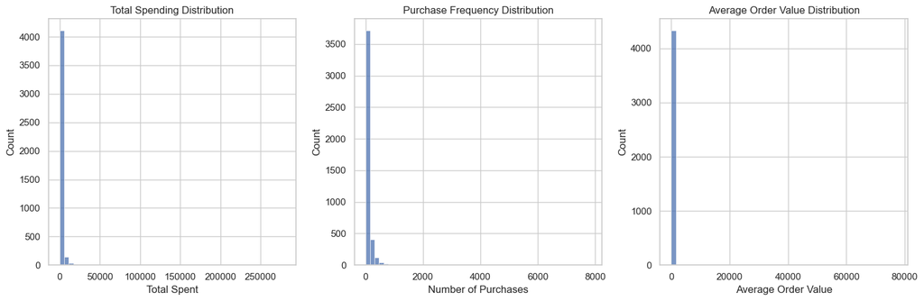

```python
def create_customer_features(df):
    """Create customer-level features for prediction"""
    if df is None:
        return None

    try:
        # Group by customer
        customer_features = df.groupby('CustomerID').agg({
            'InvoiceDate': lambda x: (x.max() - x.min()).days,  # Customer lifetime
            'InvoiceNo': 'count',  # Number of purchases
            'TotalAmount': ['sum', 'mean'],  # Spending metrics
            'Quantity': ['sum', 'mean'],  # Purchase volume
            'Description': 'nunique'  # Product variety
        })

        # Flatten column names
        customer_features.columns = [
            'customer_lifetime',
            'purchase_count',
            'total_spent',
            'avg_order_value',
            'total_items',
            'avg_items_per_order',
            'unique_products'
        ]

        # Calculate additional features
        customer_features['purchase_frequency'] = customer_features['purchase_count'] / customer_features['customer_lifetime']
        customer_features['avg_basket_size'] = customer_features['total_spent'] / customer_features['purchase_count']

        # Handle infinite values
        customer_features = customer_features.replace([np.inf, -np.inf], np.nan)
        customer_features = customer_features.fillna(0)

        return customer_features

    except Exception as e:
        print(f"Error in feature engineering: {e}")
        return None

# Create features
customer_features = create_customer_features(df_clean)
if customer_features is not None:
    print("Customer features created successfully!")
    print("Feature statistics:")
    display(customer_features.describe())

    # Visualize feature distributions
    plt.figure(figsize=(15, 5))

    plt.subplot(131)
    sns.histplot(data=customer_features['total_spent'], bins=50)
    plt.title('Total Spending Distribution')
    plt.xlabel('Total Spent')

    plt.subplot(132)
    sns.histplot(data=customer_features['purchase_count'], bins=50)
    plt.title('Purchase Frequency Distribution')
    plt.xlabel('Number of Purchases')

    plt.subplot(133)
    sns.histplot(data=customer_features['avg_order_value'], bins=50)
    plt.title('Average Order Value Distribution')
    plt.xlabel('Average Order Value')

    plt.tight_layout()
    plt.show()
```

## 3. Predictive Modeling

Implement machine learning models to predict customer behavior.

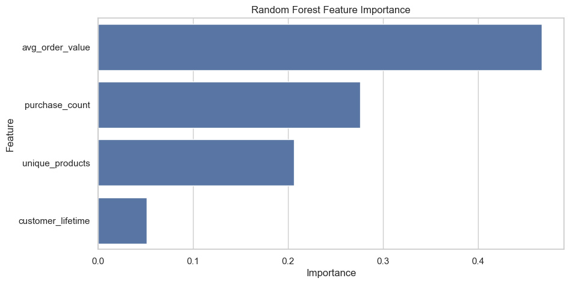

```
Model Performance Metrics:
```

|  | Random Forest | Gradient Boosting |
| --- | --- | --- |
| R2 Score | 0.759 | 0.904 |
| MAE | 417.260 | 443.750 |
| RMSE | 4972.380 | 3134.277 |

```python
def train_prediction_models(features):
    """Train and evaluate prediction models"""
    if features is None:
        return None

    try:
        # Prepare features for prediction
        X = features[['purchase_count', 'avg_order_value', 'unique_products', 'customer_lifetime']]
        y = features['total_spent']

        # Split data
        X_train, X_test, y_train, y_test = train_test_split(X, y, test_size=0.2, random_state=42)

        # Scale features
        scaler = StandardScaler()
        X_train_scaled = scaler.fit_transform(X_train)
        X_test_scaled = scaler.transform(X_test)

        # Train models
        models = {
            'Random Forest': RandomForestRegressor(n_estimators=100, random_state=42),
            'Gradient Boosting': GradientBoostingRegressor(random_state=42)
        }

        results = {}
        for name, model in models.items():
            # Train model
            model.fit(X_train_scaled, y_train)

            # Make predictions
            y_pred = model.predict(X_test_scaled)

            # Calculate metrics
            results[name] = {
                'R2 Score': r2_score(y_test, y_pred),
                'MAE': mean_absolute_error(y_test, y_pred),
                'RMSE': np.sqrt(mean_squared_error(y_test, y_pred))
            }

            # Feature importance
            if name == 'Random Forest':
                importance = pd.DataFrame({
                    'Feature': X.columns,
                    'Importance': model.feature_importances_
                }).sort_values('Importance', ascending=False)

                plt.figure(figsize=(10, 5))
                sns.barplot(data=importance, x='Importance', y='Feature')
                plt.title(f'{name} Feature Importance')
                plt.show()

        # Display results
        results_df = pd.DataFrame(results).round(3)
        print("Model Performance Metrics:")
        display(results_df)

        return models, results_df

    except Exception as e:
        print(f"Error in predictive modeling: {e}")
        return None

# Train models
model_results = train_prediction_models(customer_features)
```

## 4. Customer Segmentation

Segment customers based on their behavior patterns.

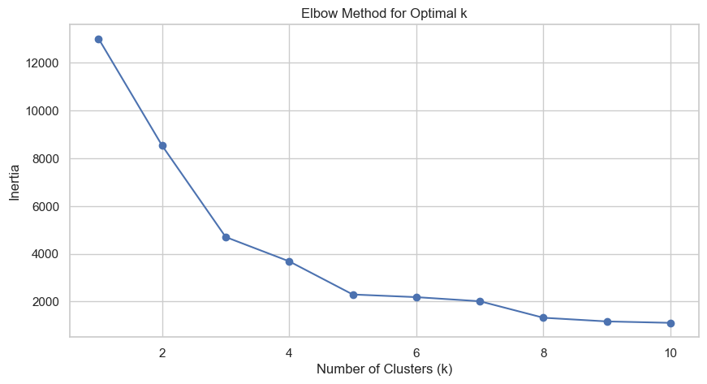

```
Cluster Analysis:
```

| Cluster | avg_total_spent | customer_count | avg_purchase_count | avg_order_value | avg_unique_products |
| --- | --- | --- | --- | --- | --- |
| 0 | 1078.43 | 4030 | 58.52 | 32.99 | 46.91 |
| 1 | 122828.05 | 2 | 2.00 | 66670.55 | 2.00 |
| 2 | 10130.01 | 296 | 444.21 | 96.52 | 237.88 |
| 3 | 132117.73 | 10 | 3056.50 | 164.97 | 883.00 |

[figure not shown]

```python
def segment_customers(features):
    """Perform customer segmentation using K-means clustering"""
    if features is None:
        return None

    try:
        # Select features for clustering
        cluster_features = features[['total_spent', 'purchase_count', 'avg_order_value']].copy()

        # Scale features
        scaler = StandardScaler()
        features_scaled = scaler.fit_transform(cluster_features)

        # Find optimal number of clusters
        inertias = []
        for k in range(1, 11):
            kmeans = KMeans(n_clusters=k, random_state=42)
            kmeans.fit(features_scaled)
            inertias.append(kmeans.inertia_)

        # Plot elbow curve
        plt.figure(figsize=(10, 5))
        plt.plot(range(1, 11), inertias, marker='o')
        plt.xlabel('Number of Clusters (k)')
        plt.ylabel('Inertia')
        plt.title('Elbow Method for Optimal k')
        plt.show()

        # Perform clustering with optimal k
        optimal_k = 4  # Based on elbow curve
        kmeans = KMeans(n_clusters=optimal_k, random_state=42)
        cluster_labels = kmeans.fit_predict(features_scaled)

        # Add cluster labels to features
        features['Cluster'] = cluster_labels

        # Analyze clusters
        cluster_analysis = features.groupby('Cluster').agg({
            'total_spent': ['mean', 'count'],
            'purchase_count': 'mean',
            'avg_order_value': 'mean',
            'unique_products': 'mean'
        }).round(2)

        # Flatten column names
        cluster_analysis.columns = [
            'avg_total_spent',
            'customer_count',
            'avg_purchase_count',
            'avg_order_value',
            'avg_unique_products'
        ]

        print("Cluster Analysis:")
        display(cluster_analysis)

        # Visualize clusters
        plt.figure(figsize=(15, 5))

        plt.subplot(131)
        sns.scatterplot(data=features, x='total_spent', y='purchase_count', hue='Cluster', palette='deep')
        plt.title('Clusters: Spending vs Purchase Frequency')

        plt.subplot(132)
        sns.scatterplot(data=features, x='avg_order_value', y='unique_products', hue='Cluster', palette='deep')
        plt.title('Clusters: Order Value vs Product Variety')

        plt.subplot(133)
        cluster_sizes = features['Cluster'].value_counts()
        plt.pie(cluster_sizes, labels=[f'Cluster {i}' for i in range(len(cluster_sizes))], autopct='%1.1f%%')
        plt.title('Cluster Sizes')

        plt.tight_layout()
        plt.show()

        return features

    except Exception as e:
        print(f"Error in customer segmentation: {e}")
        return None

# Perform segmentation
segmented_customers = segment_customers(customer_features)
```